## Tutorium 10

Gruppen 2 und 4  
Samuel Teuber  
propa@teuber.dev  
https://teuber.dev/propa

# State of the Lecture

- Verlängerte Abgabe für Übungsblatt von letzter Woche
- Erneut Änderungen am Übungblatt(!) und an Klausurrelevanz
- Heute Fokus auf Design by Contract, wegen Kürze in Vorlesung

# Klausurrelevant:

- **Parallel Fundamentals:** Amdahls Law, Task und Daten Paralellismus etc.
- **C/C++:**
  - Alles was in den Folien NICHT im Appendix steht (also Fokus auf Arbeit mit Pointern, Pointer Arithmetik und einfachen Deklarationen) à das was sie für das Arbeiten mit MPI brauchen.
  - **Ausnahme:** Präzedenzregeln und der Decoder-Ring sind *NICHT* Relevant.
- **MPI:** Alles außer MapReduce
- **Java Basic:** Thema „Memory-Consistency-Errors“ ist relevant.
- **Java Advanced:** Alles was nicht im Appendix ist, das heißt:
  - NICHT Klausurrelevant ist: Semaphores und Barriers (kommen in aktualisierter Folienversion noch in den Appendix) und anderes im Appendix
  - Klausurrelevant ist alles was in der Vorlesung dran war z.B.: Alles zu Executors, Futures, Fork-Join, Streams und Actors
- **Design by Contract:** tbd

# Nachträge zu letzter Woche

## Producer/Consumer

```
synchronized(tasks) {
    while (cond) {
        try{
            wait();
        } catch (InterruptedException e) {}
    }
}
```

`IllegalMonitorStateException`

**Richtig:**

```
synchronized(tasks) {
    while (cond) {
        try{
            tasks.wait();
        } catch (InterruptedException e) {}
    }
}
```

## `AtomicInteger`

> The specifications of these methods **enable implementations to employ efficient machine-level atomic instructions** that are available on contemporary processors. However **on some platforms, support may entail some form of internal locking**. Thus the methods are not strictly guaranteed to be non-blocking -- a thread may block transiently before performing the operation.

Quelle: https://docs.oracle.com/javase/8/docs/api/java/util/concurrent/atomic/package-summary.html

# Übungsblatt

## ...und einige Ergänzungen...

## Aufgabe 1: Amdahlsches Gesetz

Geg.: Puffer

- 90% Leser Threads: Gleichzeitig, 2s
- 10% Schreiber Threads: Blockiert, 3s

$$ P = \frac{2*0,9}{2*0,9+3*0,1} \approx 0,86\\ S(P) = \frac{1}{(1-P)+\frac{P}{N}} = \frac{1}{(1-0,86) + \frac{0,86}{4}} \approx 2,82 $$

## Aufgabe 2:

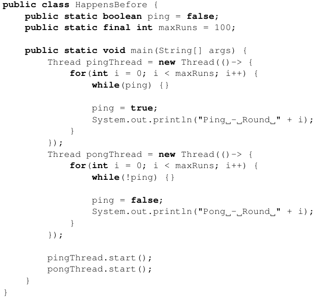

#### Problem:

Keine Happens-Before-Beziehung zwischen dem Lesen und Schreiben von `ping`  
=> Hier: Lesen/Schreiben aus/in Cache  
=> Ein Thread terminiert nicht

#### Lösung:

```
public static volatile boolean ping = false;
```

## Aufgabe 3

### Futures als Proxies

**Haskell:**

```haskell
mydef = [1,3..]
mydef !! 10
```

```
21
```

`mydef` ist ein *Proxy* der die Evaluation erst ausführt, wenn notwendig

## Aufgabe 3

### Futures als Proxies

**Java:**

```
Future<Integer> myfuture = executor.submit(() -> {
    return returnComplicatedInt();
});
```

`myfuture` ist ungefähr ein *Proxy*, der einen *in der Zukunft* auf das Ergebnis zugreifen lässt:

```
System.out.println(myfuture.get()); // blockiert bis Ergebnis
```

## Aufgabe 4

### Completable Futures

**Javascript:**

```
$.ajax("/my-page").done(function() {
    // do something
});
```

## Aufgabe 4

### Completable Futures

**Java:**

```
CompletableFuture.supplyAsync(() -> {
    return /*something complicated*/;
}).thenAccept((res) -> {/* do something */})
```

## Aufgabe 4

### Streams

**Haskell:**

```haskell
foldl max 0 (map (+1) [1,2,3,4,5])
```

```
6
```

## Aufgabe 4

### Streams

**Java:**

```
List<Integer> input = Arrays.asList(1,2,3,4,5);
int result = input.stream()
    .mapToInt(x -> x+1) // [2,3,4,5,6]
    .max() // OptionalInt
    .orElse(Integer.MIN_VALUE);
```

# Fragen zu Advanced Java?

Als nächstes:

- Aktoren
- ganz viel (?) JML

## Actor-Model

Aktoren (Threads oder Prozesse) kommunizieren per Nachrichten

Wie MPI, aber:

- Nachrichten immer asynchron
- Aktoren werden zur Laufzeit von anderen Aktoren erzeugt
- Aktoren dienen zur Abstraktion (können untersch. Code ausführen)

# Design by Contract

```
public static int binarySearch(int[] a, int key) {
    int low = 0;
    int high = a.length - 1;

    while (low <= high) {
        int mid = (low + high) / 2;
        int midVal = a[mid];

        if (midVal < key)
            low = mid + 1;
        else if (midVal > key)
            high = mid - 1;
        else
            return mid;
    }
    return -1;
}
```

**Umfrage: Was ist hier falsch?** Lösung: Overflow durch `int mid = (low + high) / 2;`

> Program testing can be used to show the presence of bugs, but never to show their absence!

Edsger W. Dijkstra

## Java Modelling Language (JML)

- **Formale** Spezifikation von Methoden
- z.B. durch Angabe von Vor- und/oder Nachbedingungen

**Warum?**

## Verwendung

- Dynamische Überprüfung zur Laufzeit: **assertions**
  - Für Fehlersuche
- **Statische** Überprüfung
  - Garantiert Eigenschaften der Software
- Als **Spezifikation**
- Zum Generieren von **Test Cases** (vgl. QuickCheck Property tests)

## Vor- und Nachbedingungen

**Syntax:** Kommentare mit @ beginnend

- Jede Bedingung: Gewöhnliche Java-Expression vom Typ `boolean`
  - Nur Expressions **ohne Seiteneffekte**
- Zusätzliche Boolsche Operatoren:
  - `==>` Implikation
  - `<==>` Äquivalenz
  - `<=!=>` XOR
- Neue Schlüsselwörter (nur für Nachbed.):
  - `\old(expr)` Wert von expr vor Methode
  - `\result` Rückgabewert

```
public int x;
public int y;
public int z;
/*@ requires y!=0;
  @ ensures \old(y)+1 == y;
  @ ensures x == \old(y);
  @*/
public void doStuff() {
    x = y++;
    z = 10/x;
}
```

## Quantoren

- Ersatz für Schleifen
- `(\forall C x; B; R)`
  - ergibt: $\forall x \in C: (B \implies R)$
- `(\exists C x; B; R)`
  - ergibt $\exists x \in C: (B \land R)$

## "Generalized Quantifiers"

- `(\sum C x; B; R)`
- `(\product C x; B; R)`
- `(\max C x; B; R)`
- `(\min C x; B; R)`
- `(\num_of C x; B; R)`

Diesmal `R` numerischer Ausdruck bzw. Boolean (`num_of`)

## Sortieren spezifizieren

```
// Mögliche Spezifikation:
/*@
  @ requires arr != null;
  @ ensures (\forall int i; 0 <= i && i < arr.length-1; arr[i] <= arr[i+1]);
  @ ensures arr.length == \old(arr.length);
  @ ensures (\forall int i; 0 <= i && i < arr.length;
  @            (\num_of int j; 0 <= j && j < arr.length;
  @               arr[i]== \old(arr[j])) ==
  @            (\num_of int j; 0 <= j && j < arr.length;
  @               arr[i] == arr[j])
  @         );
  @*/
void sort(int[] arr){/*...*/}
```

## Parameter und Attribute

- Standardmäßig nicht null
- **nullable**:

  ```
  /*@ nullable @*/ List<Integer> list
  ```

- Gilt auch für Methoden
- Welche Parameter sind veränderbar?
  - `assignable` für veränderbare Parameter
  - `assignable \nothing`

## Klasseninvarianten

- Nach jedem Konstruktoraufruf
- Vor/Nach jedem Methodenaufruf
  - Während Aufruf verletzbar
- Ähnlich: Schleifen-Invarianten

```
class IntegerSet {
    byte[] a; /* The arraya is sorted*
    /*@
      @ invariant (\forall int i;
      @                 0 <= i && i < a.length-1;
      @                 a[i]< a[i+1]);
      @*/
}
```

## Seiteneffekte

```
//...
public int doSth() {
    this.i+=10;
    return this.j;
}
/*@ requires a > 0
  @ ensures doSth() = \old(a)
  @*/
public void doSthElse(int a) {/*...*/}
//...
```

**Geht das?**

**Nein!** Denn `doSth` hat Seiteneffekte.

Jede Funktion, die aus JML aufgerufen wird darf keine Seiteneffekte haben!

```
public /*@ pure @*/ int getBalance() {/*..*/}
```

```
/*@ requires a != null && 0 < a.length < Integer.MAX_VALUE;
  @ requires (\forall int i; 0 <= i < a.length; (\forall int j; i < j < a.length; a[i] <= a[j]));
  @ ensures (\exists int i; 0 <= i < a.length; a[i] == key) <==> a[\result]==key;
  @ ensures !(\exists int i; 0 <= i < a.length; a[i] == key) <==> \result == -1;
  @*/
public static int binarySearch(int[] a, int key) {
    int low = 0;
    int high = a.length - 1;

    while (low <= high) {
        int mid = low + (high-low) / 2;
        int midVal = a[mid];

        if (midVal < key)
            low = mid + 1;
        else if (midVal > key)
            high = mid - 1;
        else
            return mid;
    }
    return -1;
}
```

- **Trusting Trust** (Ken Thompson)

  > The moral is obvious. You can't trust code that you did not totally create yourself. (Especially code from com- panies that employ people like me.)
- Auch die Spezifikation kann Fehler enthalten(!)

Tatsächlich fehlte in der Spezifikation von eben `pure`:

```
/*@ requires a != null && 0 < a.length < Integer.MAX_VALUE;
  @ requires (\forall int i; 0 <= i < a.length; (\forall int j; i < j < a.length; a[i] <= a[j]));
  @ ensures (\exists int i; 0 <= i < a.length; a[i] == key) <==> a[\result]==key;
  @ ensures !(\exists int i; 0 <= i < a.length; a[i] == value) <==> \result == -1;
  @ pure
  @*/
public static int binarySearch(int[] a, int key) {
    int low = 0;
    int high = a.length - 1;

    while (low <= high) {
        int mid = low + (high-low) / 2;
        int midVal = a[mid];

        if (midVal < key)
            low = mid + 1;
        else if (midVal > key)
            high = mid - 1;
        else
            return mid;
    }
    return -1;
}
```

```
/*@ requires a != null && 0 < a.length < Integer.MAX_VALUE;
  @ requires (\forall int i; 0 <= i < a.length; (\forall int j; i < j < a.length; a[i] <= a[j]));
  @ ensures (\exists int i; 0 <= i < a.length; a[i] == key) <==> a[\result]==key;
  @ ensures !(\exists int i; 0 <= i < a.length; a[i] == value) <==> \result == -1;
  @ pure
  @*/
public static int binarySearch(int[] a, int key) {
    int low = 0;
    int high = a.length - 1;

    while (low <= high) {
        int mid = low + (high-low) / 2;
        int midVal = a[mid];

        if (midVal < key)
            low = mid + 1;
        else if (midVal > key)
            high = mid - 1;
        else
            return mid;
    }
    return -1;
}
```

`binarySearch(null,4);`

Aufrufer verletzt Spezifikation

```
/*@ requires a != null && 0 < a.length < Integer.MAX_VALUE;
  @ requires (\forall int i; 0 <= i < a.length; (\forall int j; i < j < a.length; a[i] <= a[j]));
  @ ensures (\exists int i; 0 <= i < a.length; a[i] == key) <==> a[\result]==key;
  @ ensures !(\exists int i; 0 <= i < a.length; a[i] == value) <==> \result == -1;
  @ pure
  @*/
public static int binarySearch(int[] a, int key) {
    int low = 0;
    int high = a.length - 1;

    while (low <= high) {
        int mid = low + (high-low) / 2;
        int midVal = a[mid];

        if (midVal < key)
            low = mid + 1;
        else if (midVal > key)
            high = mid - 1;
        else
            return mid+1;
    }
    return -1;
}
```

`binarySearch(new int[]{1,2,3,4,5},4);`

Aufgerufene Funktion verletzt Spezifikation (`return mid+1;`)

## Liskovsches Substitutionsprinzip

**Barbara Liskov**

> Subtype Requirement:  
> Let $\Phi(x)$ be a property provable about objects $x$ of type $T$.  
> Then $\Phi(y)$ should be true for objects $y$ of type $S$ where $S$ is a subtype of $T$.
- Schwächere Vorbedingungen
- Stärkere Nachbedingungen

# Ansonsten...

### Private Behavior

```
private/*@ spec_public@*/ int size = 0;
// ....
/*@ ensures \result!= null;
  @ private behavior
  @ requires size > 0;
  @*/
Object pop() { /*...pop logic ...*/ }
```

### Assertions als Contracts

```
Object pop() {
    assert size > 0;
    int _oldSize = size;
    int _oldTop = top();
    // pop logic
    assert size == _oldSize-1;
    assert result == _oldTop;
    return result;
}
```